# 06 Offline Synthetic Expansion

This notebook evaluates deterministic virtual synthetic add-back for optic disc and cup segmentation.

The core design is intentionally storage-light:

- the original public-data manifest remains the only image/mask source;
- synthetic training examples are generated on demand inside the training dataset;
- validation and test data remain original and unaltered;
- only lightweight training plans, summaries, histories, and comparison tables are saved.

## 06.01 — Imports

Import general utilities used throughout the notebook.

```python
# 06.01 — Imports
from __future__ import annotations

import json
import math
import os
import sys
import time
from pathlib import Path
from typing import Any

import matplotlib.pyplot as plt
import numpy as np
import pandas as pd
import torch
from IPython.display import display
from torch.utils.data import DataLoader, Subset
```

## 06.02 — Project root and source path setup

Find the repository root and make local source modules importable from the notebook kernel.

```python
# 06.02 — Project root and source path setup
def find_project_root(start: Path | None = None) -> Path:
    """Find the repository root from a notebook or terminal working directory."""
    current = (start or Path.cwd()).resolve()

    for candidate in [current, *current.parents]:
        if (candidate / ".git").exists() and (candidate / "src").exists():
            return candidate

    raise FileNotFoundError("Could not find project root containing .git and src/.")


PROJECT_ROOT = find_project_root()
SRC_PATH = PROJECT_ROOT / "src"

if str(SRC_PATH) not in sys.path:
    sys.path.insert(0, str(SRC_PATH))

os.chdir(PROJECT_ROOT)

print(f"Project root: {PROJECT_ROOT}")
print(f"Source path:  {SRC_PATH}")
```

```
Project root: /sfs/gpfs/tardis/home/gsr3qz/Documents/MSDS/CAPSTONE/GitHub/Automated-Glaucoma-Screening-Using-AI-Enhanced-Ophthalmoscopy
Source path:  /sfs/gpfs/tardis/home/gsr3qz/Documents/MSDS/CAPSTONE/GitHub/Automated-Glaucoma-Screening-Using-AI-Enhanced-Ophthalmoscopy/src
```

## 06.03 — Environment and phase-06 directory setup

Record the active Python/PyTorch environment and define the lightweight output paths used by this phase.

```python
# 06.03 — Environment and phase-06 directory setup
REPORTS_DIR = PROJECT_ROOT / "reports"
TRAINING_REPORTS_DIR = REPORTS_DIR / "training"
DATA_AUDIT_REPORTS_DIR = REPORTS_DIR / "data_audit"

TRAINING_REPORTS_DIR.mkdir(parents=True, exist_ok=True)
DATA_AUDIT_REPORTS_DIR.mkdir(parents=True, exist_ok=True)

print("Python executable:", sys.executable)
print("Python version:", sys.version.split()[0])
print("PyTorch version:", torch.__version__)
print("CUDA available:", torch.cuda.is_available())

if torch.cuda.is_available():
    print("CUDA device count:", torch.cuda.device_count())
    print("Current CUDA device:", torch.cuda.get_device_name(torch.cuda.current_device()))
```

```
Python executable: /home/gsr3qz/.conda/envs/glaucoma-capstone/bin/python
Python version: 3.11.15
PyTorch version: 2.4.0
CUDA available: True
CUDA device count: 1
Current CUDA device: NVIDIA RTX A6000
```

## 06.04 — Input manifest and Notebook 05 handoff verification

Verify that the combined split manifest and Notebook 05 online-augmentation outputs are present.

```python
# 06.04 — Input manifest and Notebook 05 handoff verification
MANIFEST_PATH = PROJECT_ROOT / "data/processed/manifests/combined_segmentation_manifest_with_splits.csv"

NOTEBOOK_05_OUTPUTS = {
    "model_baselines": TRAINING_REPORTS_DIR / "online_augmentation_model_baselines.csv",
    "strategy_summary": TRAINING_REPORTS_DIR / "online_augmentation_strategy_summary.csv",
    "independent_summary": TRAINING_REPORTS_DIR / "online_augmentation_independent_summary.csv",
    "independent_winners": TRAINING_REPORTS_DIR / "online_augmentation_independent_winners.csv",
    "screen_summary": TRAINING_REPORTS_DIR / "online_augmentation_screen_summary.csv",
}

required_paths = {"combined_manifest": MANIFEST_PATH, **NOTEBOOK_05_OUTPUTS}
path_check = pd.DataFrame(
    [
        {
            "artifact": name,
            "path": str(path.relative_to(PROJECT_ROOT)),
            "exists": path.exists(),
            "size_kb": round(path.stat().st_size / 1024, 2) if path.exists() else np.nan,
        }
        for name, path in required_paths.items()
    ]
)

display(path_check)

missing = path_check.loc[~path_check["exists"], "artifact"].tolist()
if missing:
    raise FileNotFoundError(f"Missing required Notebook 06 inputs: {missing}")

manifest = pd.read_csv(MANIFEST_PATH)

split_summary = (
    manifest.groupby("split", dropna=False)
    .size()
    .reset_index(name="rows")
    .sort_values("split")
)

source_split_summary = (
    manifest.groupby(["source_dataset", "split"], dropna=False)
    .size()
    .reset_index(name="rows")
    .sort_values(["source_dataset", "split"])
)

print(f"Combined manifest rows: {len(manifest):,}")
display(split_summary)
display(source_split_summary)
```

|  | artifact | path | exists | size_kb |
| --- | --- | --- | --- | --- |
| 0 | combined_manifest | data/processed/manifests/combined_segmentation... | True | 665.57 |
| 1 | model_baselines | reports/training/online_augmentation_model_bas... | True | 0.77 |
| 2 | strategy_summary | reports/training/online_augmentation_strategy_... | True | 1.16 |
| 3 | independent_summary | reports/training/online_augmentation_independe... | True | 12.46 |
| 4 | independent_winners | reports/training/online_augmentation_independe... | True | 7.53 |
| 5 | screen_summary | reports/training/online_augmentation_screen_su... | True | 15.07 |

```
Combined manifest rows: 3,358
```

|  | split | rows |
| --- | --- | --- |
| 0 | test | 722 |
| 1 | train | 1911 |
| 2 | val | 725 |

|  | source_dataset | split | rows |
| --- | --- | --- | --- |
| 0 | G1020 | test | 153 |
| 1 | G1020 | train | 714 |
| 2 | G1020 | val | 153 |
| 3 | ORIGA | test | 97 |
| 4 | ORIGA | train | 455 |
| 5 | ORIGA | val | 98 |
| 6 | PAPILA | test | 72 |
| 7 | PAPILA | train | 342 |
| 8 | PAPILA | val | 74 |
| 9 | REFUGE | test | 400 |
| 10 | REFUGE | train | 400 |
| 11 | REFUGE | val | 400 |

## 06.05 — Core project module import check

Import the source-backed helpers needed for deterministic virtual synthetic expansion and training.

```python
# 06.05 — Core project module import check
from glaucoma_segmentation.augmentation import (
    build_virtual_synthetic_expansion_dataset,
    summarize_virtual_synthetic_expansion,
)
from glaucoma_segmentation.data.dataloaders import make_segmentation_datasets
from glaucoma_segmentation.nets.losses import DiceCELoss
from glaucoma_segmentation.nets.model_factory import build_model
from glaucoma_segmentation.training.train_loop import extract_images_and_masks, model_forward
from glaucoma_segmentation.utils.device import describe_device, get_device
from glaucoma_segmentation.utils.seed import seed_everything

print("Project module imports: OK")
```

```
Project module imports: OK
```

## 06.06 — Dice-first Notebook 06 configuration

Use the same image size, model family, and Dice-first comparison logic established in the prior modeling notebooks.

```python
# 06.06 — Dice-first Notebook 06 configuration
SEED = 42
IMAGE_SIZE = (256, 256)
BATCH_SIZE = 8
SMOKE_BATCH_SIZE = 4
NUM_WORKERS = 4 if torch.cuda.is_available() else 0
PIN_MEMORY = bool(torch.cuda.is_available())
EPOCHS = 5
PRIMARY_DICE_IMPROVEMENT_THRESHOLD = 0.005
SYNTHETIC_COPY_COUNT = 1

seed_config = seed_everything(SEED, deterministic=False)

config_summary = pd.DataFrame(
    [
        {"setting": "seed", "value": SEED},
        {"setting": "image_size", "value": str(IMAGE_SIZE)},
        {"setting": "batch_size", "value": BATCH_SIZE},
        {"setting": "smoke_batch_size", "value": SMOKE_BATCH_SIZE},
        {"setting": "num_workers", "value": NUM_WORKERS},
        {"setting": "pin_memory", "value": PIN_MEMORY},
        {"setting": "epochs", "value": EPOCHS},
        {"setting": "synthetic_copy_count", "value": SYNTHETIC_COPY_COUNT},
        {"setting": "primary_dice_improvement_threshold", "value": PRIMARY_DICE_IMPROVEMENT_THRESHOLD},
    ]
)

display(config_summary)
print(seed_config)
```

|  | setting | value |
| --- | --- | --- |
| 0 | seed | 42 |
| 1 | image_size | (256, 256) |
| 2 | batch_size | 8 |
| 3 | smoke_batch_size | 4 |
| 4 | num_workers | 4 |
| 5 | pin_memory | True |
| 6 | epochs | 5 |
| 7 | synthetic_copy_count | 1 |
| 8 | primary_dice_improvement_threshold | 0.005 |

```
SeedConfig(seed=42, deterministic=False, cudnn_benchmark=None)
```

## 06.07 — Select synthetic expansion candidates from Notebook 05 winners

Focus first on the strongest individual online-augmentation winners instead of bundled combined policies.

```python
# 06.07 — Select synthetic expansion candidates from Notebook 05 winners
screen_summary = pd.read_csv(NOTEBOOK_05_OUTPUTS["screen_summary"])
model_baselines = pd.read_csv(NOTEBOOK_05_OUTPUTS["model_baselines"])

CORE_SYNTHETIC_CANDIDATES = pd.DataFrame(
    [
        {
            "run_name": "synthetic_unetplusplus_resnet18_small_affine_256px_5epoch",
            "model_name": "unetplusplus",
            "encoder_name": "resnet18",
            "strategy_name": "small_affine",
            "candidate_role": "best_overall_online_individual_result",
        },
        {
            "run_name": "synthetic_unet_resnet18_vignette_illumination_256px_5epoch",
            "model_name": "unet",
            "encoder_name": "resnet18",
            "strategy_name": "vignette_illumination",
            "candidate_role": "best_unet_online_individual_result",
        },
    ]
)


def first_existing_column(frame: pd.DataFrame, names: list[str]) -> str | None:
    """Return the first matching column name in a dataframe."""
    for name in names:
        if name in frame.columns:
            return name
    return None


def attach_notebook05_metrics(candidates: pd.DataFrame, screen: pd.DataFrame) -> pd.DataFrame:
    """Attach Notebook 05 online-screen metrics when matching columns are available."""
    model_col = first_existing_column(screen, ["model_name", "model"])
    encoder_col = first_existing_column(screen, ["encoder_name", "encoder"])
    strategy_col = first_existing_column(screen, ["strategy_name", "augmentation_strategy", "augmentation"])

    metric_cols = [
        col
        for col in [
            "best_val_mean_foreground_dice",
            "mean_foreground_dice",
            "delta_vs_model_baseline",
            "delta_mean_foreground_dice_vs_baseline",
            "meaningful_primary_improvement",
            "best_val_disc_dice",
            "best_val_cup_dice",
            "best_val_cdr_mae",
        ]
        if col in screen.columns
    ]

    if model_col is None or encoder_col is None or strategy_col is None:
        print("Notebook 05 screen summary columns:")
        print(list(screen.columns))
        print("Could not attach metrics automatically; candidate plan remains explicit.")
        return candidates

    slim = screen[[model_col, encoder_col, strategy_col, *metric_cols]].copy()
    slim = slim.rename(
        columns={
            model_col: "model_name",
            encoder_col: "encoder_name",
            strategy_col: "strategy_name",
        }
    )

    return candidates.merge(
        slim,
        on=["model_name", "encoder_name", "strategy_name"],
        how="left",
    )


synthetic_candidates = attach_notebook05_metrics(CORE_SYNTHETIC_CANDIDATES, screen_summary)

display(synthetic_candidates)
```

|  | run_name | model_name | encoder_name | strategy_name | candidate_role | best_val_mean_foreground_dice | best_val_disc_dice | best_val_cup_dice | best_val_cdr_mae |
| --- | --- | --- | --- | --- | --- | --- | --- | --- | --- |
| 0 | synthetic_unetplusplus_resnet18_small_affine_2... | unetplusplus | resnet18 | small_affine | best_overall_online_individual_result | 0.811561 | 0.841416 | 0.781706 | 0.068719 |
| 1 | synthetic_unet_resnet18_vignette_illumination_... | unet | resnet18 | vignette_illumination | best_unet_online_individual_result | 0.803803 | 0.829354 | 0.778252 | 0.072379 |

## 06.08 — Build original split datasets

Build original train, validation, and test datasets from the existing split-aware manifest. Only the training dataset will be wrapped for virtual synthetic expansion.

```python
# 06.08 — Build original split datasets
datasets = make_segmentation_datasets(
    manifest_path=MANIFEST_PATH,
    image_size=IMAGE_SIZE,
    validate_paths=True,
    validate_masks=False,
)

dataset_size_summary = pd.DataFrame(
    [
        {"split": "train", "rows": len(datasets.train), "wrapped_for_synthetic_training": True},
        {"split": "val", "rows": len(datasets.val), "wrapped_for_synthetic_training": False},
        {"split": "test", "rows": len(datasets.test), "wrapped_for_synthetic_training": False},
    ]
)

display(dataset_size_summary)
```

|  | split | rows | wrapped_for_synthetic_training |
| --- | --- | --- | --- |
| 0 | train | 1911 | True |
| 1 | val | 725 | False |
| 2 | test | 722 | False |

## 06.09 — Build virtual synthetic expansion datasets

Create storage-light virtual training datasets for the selected candidate strategies.

```python
# 06.09 — Build virtual synthetic expansion datasets
virtual_train_datasets = {}
virtual_summary_rows = []

for candidate in synthetic_candidates.to_dict("records"):
    run_name = candidate["run_name"]
    strategy_name = candidate["strategy_name"]

    virtual_dataset = build_virtual_synthetic_expansion_dataset(
        datasets.train,
        strategy_names=strategy_name,
        copy_count=SYNTHETIC_COPY_COUNT,
        base_seed=SEED,
        include_original=True,
        add_metadata=True,
    )

    virtual_train_datasets[run_name] = virtual_dataset

    summary = virtual_dataset.summary().to_dict()
    summary.update(
        {
            "run_name": run_name,
            "model_name": candidate["model_name"],
            "encoder_name": candidate["encoder_name"],
            "strategy_name": strategy_name,
        }
    )
    virtual_summary_rows.append(summary)

virtual_expansion_summary = pd.DataFrame(virtual_summary_rows)
display(virtual_expansion_summary)
```

|  | base_rows | original_rows_exposed | synthetic_rows_exposed | total_rows_exposed | base_seed | include_original | strategies | copy_counts | run_name | model_name | encoder_name | strategy_name |
| --- | --- | --- | --- | --- | --- | --- | --- | --- | --- | --- | --- | --- |
| 0 | 1911 | 1911 | 1911 | 3822 | 42 | True | small_affine | 1 | synthetic_unetplusplus_resnet18_small_affine_2... | unetplusplus | resnet18 | small_affine |
| 1 | 1911 | 1911 | 1911 | 3822 | 42 | True | vignette_illumination | 1 | synthetic_unet_resnet18_vignette_illumination_... | unet | resnet18 | vignette_illumination |

## 06.10 — Virtual index and determinism QA

Check that virtual indices map back to original training rows and that repeated access to the same synthetic row is deterministic.

```python
# 06.10 — Virtual index and determinism QA
qa_run_name = synthetic_candidates.iloc[0]["run_name"]
qa_dataset = virtual_train_datasets[qa_run_name]

preview_indices = [
    0,
    1,
    len(datasets.train) - 1,
    len(datasets.train),
    len(datasets.train) + 1,
    len(qa_dataset) - 1,
]

index_preview = pd.DataFrame([qa_dataset.map_index(index).to_dict() for index in preview_indices])
display(index_preview)

synthetic_index = len(datasets.train)
synthetic_a = qa_dataset[synthetic_index]
synthetic_b = qa_dataset[synthetic_index]

determinism_check = {
    "qa_run_name": qa_run_name,
    "synthetic_index": synthetic_index,
    "same_image_repeated_access": torch.equal(synthetic_a["image"], synthetic_b["image"]),
    "same_mask_repeated_access": torch.equal(synthetic_a["mask"], synthetic_b["mask"]),
    "synthetic_seed": int(synthetic_a["synthetic_seed"]),
    "synthetic_strategy": synthetic_a["synthetic_strategy"],
}

display(pd.DataFrame([determinism_check]))

if not determinism_check["same_image_repeated_access"] or not determinism_check["same_mask_repeated_access"]:
    raise RuntimeError("Virtual synthetic determinism check failed.")
```

|  | virtual_index | source_index | is_synthetic | strategy_name | copy_index | synthetic_seed |
| --- | --- | --- | --- | --- | --- | --- |
| 0 | 0 | 0 | False | none | -1 | -1 |
| 1 | 1 | 1 | False | none | -1 | -1 |
| 2 | 1910 | 1910 | False | none | -1 | -1 |
| 3 | 1911 | 0 | True | small_affine | 0 | 1823203 |
| 4 | 1912 | 1 | True | small_affine | 0 | 2823206 |
| 5 | 3821 | 1910 | True | small_affine | 0 | 1911828933 |

|  | qa_run_name | synthetic_index | same_image_repeated_access | same_mask_repeated_access | synthetic_seed | synthetic_strategy |
| --- | --- | --- | --- | --- | --- | --- |
| 0 | synthetic_unetplusplus_resnet18_small_affine_2... | 1911 | True | True | 1823203 | small_affine |

## 06.11 — Visual QA for virtual synthetic examples

Compare original training samples with their deterministic virtual synthetic counterparts.

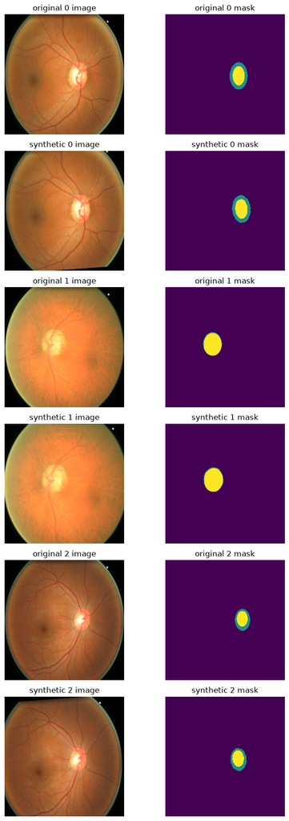

```python
# 06.11 — Visual QA for virtual synthetic examples
def tensor_image_to_numpy(image: torch.Tensor) -> np.ndarray:
    """Convert a CHW float tensor image to HWC numpy format for display."""
    return image.detach().cpu().permute(1, 2, 0).numpy().clip(0, 1)


def tensor_mask_to_numpy(mask: torch.Tensor) -> np.ndarray:
    """Convert a mask tensor to a numpy array for display."""
    return mask.detach().cpu().numpy()


example_source_indices = [0, 1, 2]
figure_rows = []

for source_index in example_source_indices:
    original_sample = qa_dataset[source_index]
    synthetic_sample = qa_dataset[len(datasets.train) + source_index]
    figure_rows.append((f"original {source_index}", original_sample))
    figure_rows.append((f"synthetic {source_index}", synthetic_sample))

fig, axes = plt.subplots(len(figure_rows), 2, figsize=(8, 3 * len(figure_rows)))

if len(figure_rows) == 1:
    axes = np.array([axes])

for row_index, (label, sample) in enumerate(figure_rows):
    axes[row_index, 0].imshow(tensor_image_to_numpy(sample["image"]))
    axes[row_index, 0].set_title(f"{label} image")
    axes[row_index, 0].axis("off")

    axes[row_index, 1].imshow(tensor_mask_to_numpy(sample["mask"]), vmin=0, vmax=2)
    axes[row_index, 1].set_title(f"{label} mask")
    axes[row_index, 1].axis("off")

plt.tight_layout()
plt.show()
```

## 06.12 — Virtual synthetic DataLoader smoke test

Confirm that original and synthetic rows collate correctly in a PyTorch DataLoader.

```python
# 06.12 — Virtual synthetic DataLoader smoke test
mixed_indices = [0, 1, len(datasets.train), len(datasets.train) + 1]
mixed_subset = Subset(qa_dataset, mixed_indices)

smoke_loader = DataLoader(
    mixed_subset,
    batch_size=SMOKE_BATCH_SIZE,
    shuffle=False,
    num_workers=0,
    pin_memory=False,
)

smoke_batch = next(iter(smoke_loader))
smoke_images, smoke_masks = extract_images_and_masks(smoke_batch)

dataloader_smoke_summary = pd.DataFrame(
    [
        {
            "batch_size": int(smoke_images.shape[0]),
            "image_shape": str(tuple(smoke_images.shape)),
            "mask_shape": str(tuple(smoke_masks.shape)),
            "image_dtype": str(smoke_images.dtype),
            "mask_dtype": str(smoke_masks.dtype),
            "mask_values": str(sorted(torch.unique(smoke_masks).tolist())),
            "synthetic_flags": str(smoke_batch["is_synthetic"].tolist()),
            "synthetic_strategies": str(smoke_batch["synthetic_strategy"]),
        }
    ]
)

display(dataloader_smoke_summary)

assert tuple(smoke_images.shape) == (SMOKE_BATCH_SIZE, 3, IMAGE_SIZE[1], IMAGE_SIZE[0])
assert tuple(smoke_masks.shape) == (SMOKE_BATCH_SIZE, IMAGE_SIZE[1], IMAGE_SIZE[0])
assert set(torch.unique(smoke_masks).tolist()).issubset({0, 1, 2})
assert smoke_batch["is_synthetic"].tolist() == [False, False, True, True]
```

|  | batch_size | image_shape | mask_shape | image_dtype | mask_dtype | mask_values | synthetic_flags | synthetic_strategies |
| --- | --- | --- | --- | --- | --- | --- | --- | --- |
| 0 | 4 | (4, 3, 256, 256) | (4, 256, 256) | torch.float32 | torch.int64 | [0, 1, 2] | [False, False, True, True] | ['none', 'none', 'small_affine', 'small_affine'] |

## 06.13 — Model and loss smoke test

Run one small forward/loss pass to verify that the virtual expanded data is compatible with the existing training stack.

```python
# 06.13 — Model and loss smoke test
device = get_device()
device_info = describe_device(device)
print(device_info)

smoke_candidate = synthetic_candidates.iloc[0].to_dict()

smoke_model = build_model(
    model_name=smoke_candidate["model_name"],
    encoder_name=smoke_candidate["encoder_name"],
    encoder_weights=None,
    in_channels=3,
    classes=3,
)

criterion = DiceCELoss()

with torch.no_grad():
    smoke_logits = model_forward(smoke_model.to(device), smoke_images.to(device))
    smoke_loss = criterion(smoke_logits, smoke_masks.to(device))

model_smoke_summary = pd.DataFrame(
    [
        {
            "run_name": smoke_candidate["run_name"],
            "model_name": smoke_candidate["model_name"],
            "encoder_name": smoke_candidate["encoder_name"],
            "strategy_name": smoke_candidate["strategy_name"],
            "device": str(device),
            "logits_shape": str(tuple(smoke_logits.shape)),
            "smoke_loss": float(smoke_loss.detach().cpu().item()),
        }
    ]
)

display(model_smoke_summary)

del smoke_model, smoke_logits, smoke_loss
if torch.cuda.is_available():
    torch.cuda.empty_cache()
```

```
DeviceInfo(device='cuda', device_type='cuda', name='NVIDIA RTX A6000', cuda_available=True, cuda_device_count=1, mps_available=False)
```

|  | run_name | model_name | encoder_name | strategy_name | device | logits_shape | smoke_loss |
| --- | --- | --- | --- | --- | --- | --- | --- |
| 0 | synthetic_unetplusplus_resnet18_small_affine_2... | unetplusplus | resnet18 | small_affine | cuda | (4, 3, 256, 256) | 2.836088 |

## 06.14 — Save lightweight setup summaries

Save only small CSV summaries. No synthetic images, masks, checkpoints, or expanded datasets are written.

```python
# 06.14 — Save lightweight setup summaries
VIRTUAL_SUMMARY_PATH = DATA_AUDIT_REPORTS_DIR / "virtual_synthetic_expansion_summary.csv"
VIRTUAL_INDEX_PREVIEW_PATH = DATA_AUDIT_REPORTS_DIR / "virtual_synthetic_index_preview.csv"
SYNTHETIC_TRAINING_PLAN_PATH = TRAINING_REPORTS_DIR / "synthetic_expansion_training_plan.csv"

virtual_expansion_summary.to_csv(VIRTUAL_SUMMARY_PATH, index=False)
index_preview.to_csv(VIRTUAL_INDEX_PREVIEW_PATH, index=False)

synthetic_training_plan = synthetic_candidates.copy()
synthetic_training_plan["epochs"] = EPOCHS
synthetic_training_plan["image_size"] = str(IMAGE_SIZE)
synthetic_training_plan["batch_size"] = BATCH_SIZE
synthetic_training_plan["num_workers"] = NUM_WORKERS
synthetic_training_plan["pin_memory"] = PIN_MEMORY
synthetic_training_plan["synthetic_copy_count"] = SYNTHETIC_COPY_COUNT
synthetic_training_plan["base_seed"] = SEED
synthetic_training_plan["materializes_synthetic_files"] = False
synthetic_training_plan.to_csv(SYNTHETIC_TRAINING_PLAN_PATH, index=False)

saved_outputs = pd.DataFrame(
    [
        {"artifact": "virtual_expansion_summary", "path": str(VIRTUAL_SUMMARY_PATH.relative_to(PROJECT_ROOT))},
        {"artifact": "virtual_index_preview", "path": str(VIRTUAL_INDEX_PREVIEW_PATH.relative_to(PROJECT_ROOT))},
        {"artifact": "synthetic_training_plan", "path": str(SYNTHETIC_TRAINING_PLAN_PATH.relative_to(PROJECT_ROOT))},
    ]
)

display(saved_outputs)
```

|  | artifact | path |
| --- | --- | --- |
| 0 | virtual_expansion_summary | reports/data_audit/virtual_synthetic_expansion... |
| 1 | virtual_index_preview | reports/data_audit/virtual_synthetic_index_pre... |
| 2 | synthetic_training_plan | reports/training/synthetic_expansion_training_... |

## 06.15 — Notebook 06 setup handoff summary

Summarize readiness for the training cells that will be run next.

```python
# 06.15 — Notebook 06 setup handoff summary
handoff_summary = pd.DataFrame(
    [
        {"item": "combined manifest", "status": "ready", "detail": f"{len(manifest):,} rows"},
        {"item": "original train rows", "status": "ready", "detail": f"{len(datasets.train):,} rows"},
        {"item": "validation rows", "status": "unchanged", "detail": f"{len(datasets.val):,} rows"},
        {"item": "test rows", "status": "unchanged", "detail": f"{len(datasets.test):,} rows"},
        {"item": "virtual synthetic add-back", "status": "ready", "detail": "generated on demand; no synthetic files saved"},
        {"item": "candidate runs", "status": "planned", "detail": f"{len(synthetic_candidates)} core runs"},
        {"item": "training", "status": "not started", "detail": "add separate runnable cells for each planned run"},
    ]
)

display(handoff_summary)
```

|  | item | status | detail |
| --- | --- | --- | --- |
| 0 | combined manifest | ready | 3,358 rows |
| 1 | original train rows | ready | 1,911 rows |
| 2 | validation rows | unchanged | 725 rows |
| 3 | test rows | unchanged | 722 rows |
| 4 | virtual synthetic add-back | ready | generated on demand; no synthetic files saved |
| 5 | candidate runs | planned | 2 core runs |
| 6 | training | not started | add separate runnable cells for each planned run |

## 06.16 — Synthetic expansion training helpers

Define reusable helpers for the virtual synthetic add-back training runs. Each planned experiment will still be launched from its own notebook cell.

```python
# 06.16 — Synthetic expansion training helpers
from glaucoma_segmentation.training.train_loop import fit_model_with_progress, history_to_dicts

LEARNING_RATE = 1e-4
WEIGHT_DECAY = 1e-4

SYNTHETIC_HISTORY_PATH = TRAINING_REPORTS_DIR / "synthetic_expansion_training_history.csv"
SYNTHETIC_METADATA_PATH = TRAINING_REPORTS_DIR / "synthetic_expansion_run_metadata.csv"
SYNTHETIC_SUMMARY_PATH = TRAINING_REPORTS_DIR / "synthetic_expansion_summary.csv"


def mean_foreground_dice_from_columns(frame: pd.DataFrame) -> pd.Series:
    """Compute mean foreground Dice from disc and cup Dice columns."""
    return (frame["disc_dice"].astype(float) + frame["cup_dice"].astype(float)) / 2.0


def load_csv_if_exists(path: Path) -> pd.DataFrame:
    """Load a CSV if it exists; otherwise return an empty dataframe."""
    if path.exists():
        return pd.read_csv(path)
    return pd.DataFrame()


def remove_run_if_present(frame: pd.DataFrame, run_name: str) -> pd.DataFrame:
    """Remove an existing run from a dataframe before overwriting it."""
    if frame.empty or "run_name" not in frame.columns:
        return frame
    return frame.loc[frame["run_name"] != run_name].copy()


def append_run_rows(path: Path, new_rows: pd.DataFrame, run_name: str, overwrite: bool) -> pd.DataFrame:
    """Append run rows to a CSV, optionally replacing prior rows for the same run."""
    existing = load_csv_if_exists(path)

    if overwrite:
        existing = remove_run_if_present(existing, run_name)

    combined = pd.concat([existing, new_rows], ignore_index=True)
    combined.to_csv(path, index=False)
    return combined


def summarize_history_for_run(history_frame: pd.DataFrame, run_name: str) -> pd.DataFrame:
    """Return the Dice-first best validation row for one run."""
    if history_frame.empty:
        return pd.DataFrame()

    run_history = history_frame.loc[history_frame["run_name"] == run_name].copy()
    val_history = run_history.loc[run_history["phase"] == "val"].copy()

    if val_history.empty:
        return pd.DataFrame()

    val_history["val_mean_foreground_dice"] = mean_foreground_dice_from_columns(val_history)
    val_history = val_history.sort_values(
        ["val_mean_foreground_dice", "cup_dice", "disc_dice"],
        ascending=[False, False, False],
    )

    best = val_history.head(1).copy()
    best = best.rename(
        columns={
            "epoch": "best_epoch_by_val_mean_foreground_dice",
            "loss": "best_val_loss",
            "disc_dice": "best_val_disc_dice",
            "cup_dice": "best_val_cup_dice",
            "cdr_mae": "best_val_cdr_mae",
            "n_images": "val_images",
            "n_batches": "val_batches",
        }
    )

    return best[
        [
            "run_name",
            "best_epoch_by_val_mean_foreground_dice",
            "best_val_loss",
            "best_val_disc_dice",
            "best_val_cup_dice",
            "best_val_cdr_mae",
            "val_mean_foreground_dice",
            "val_images",
            "val_batches",
        ]
    ]


def candidate_for_run(run_name: str) -> dict[str, Any]:
    """Return the training-plan row for a run name."""
    matches = synthetic_training_plan.loc[synthetic_training_plan["run_name"] == run_name]

    if len(matches) != 1:
        raise ValueError(f"Expected exactly one candidate for run_name={run_name!r}, got {len(matches)}.")

    return matches.iloc[0].to_dict()


def make_training_loaders_for_run(run_name: str) -> tuple[DataLoader, DataLoader]:
    """Build training and validation loaders for a virtual synthetic run."""
    train_dataset = virtual_train_datasets[run_name]

    train_generator = torch.Generator()
    train_generator.manual_seed(SEED)

    train_loader = DataLoader(
        train_dataset,
        batch_size=BATCH_SIZE,
        shuffle=True,
        num_workers=NUM_WORKERS,
        pin_memory=PIN_MEMORY,
        generator=train_generator,
        drop_last=False,
    )

    val_loader = DataLoader(
        datasets.val,
        batch_size=BATCH_SIZE,
        shuffle=False,
        num_workers=NUM_WORKERS,
        pin_memory=PIN_MEMORY,
        drop_last=False,
    )

    return train_loader, val_loader


def run_virtual_synthetic_training(run_name: str, *, overwrite: bool = False) -> pd.DataFrame:
    """Run one virtual synthetic expansion experiment and save lightweight results."""
    existing_history = load_csv_if_exists(SYNTHETIC_HISTORY_PATH)

    if (
        not overwrite
        and not existing_history.empty
        and "run_name" in existing_history.columns
        and run_name in set(existing_history["run_name"])
    ):
        print(f"Existing results found for {run_name}. Set overwrite=True to rerun.")
        existing_summary = summarize_history_for_run(existing_history, run_name)
        display(existing_summary)
        return existing_summary

    candidate = candidate_for_run(run_name)
    train_loader, val_loader = make_training_loaders_for_run(run_name)
    device = get_device()

    print(f"Run name: {run_name}")
    print(f"Model: {candidate['model_name']} / {candidate['encoder_name']}")
    print(f"Virtual synthetic strategy: {candidate['strategy_name']}")
    print(f"Training rows exposed: {len(virtual_train_datasets[run_name]):,}")
    print(f"Validation rows: {len(datasets.val):,}")
    print(f"Device: {device}")

    seed_everything(SEED, deterministic=False)

    model = build_model(
        model_name=candidate["model_name"],
        encoder_name=candidate["encoder_name"],
        encoder_weights=None,
        in_channels=3,
        classes=3,
    )

    criterion = DiceCELoss()
    optimizer = torch.optim.AdamW(
        model.parameters(),
        lr=LEARNING_RATE,
        weight_decay=WEIGHT_DECAY,
    )

    start_time = time.perf_counter()

    history = fit_model_with_progress(
        model=model,
        train_loader=train_loader,
        val_loader=val_loader,
        criterion=criterion,
        optimizer=optimizer,
        device=device,
        epochs=EPOCHS,
        run_name=run_name,
        image_size=IMAGE_SIZE,
        batch_size=BATCH_SIZE,
        print_epoch_summary=True,
        leave_progress=False,
    )

    elapsed_minutes = (time.perf_counter() - start_time) / 60.0

    history_frame = pd.DataFrame(history_to_dicts(history))
    history_frame.insert(0, "run_name", run_name)
    history_frame.insert(1, "model_name", candidate["model_name"])
    history_frame.insert(2, "encoder_name", candidate["encoder_name"])
    history_frame.insert(3, "strategy_name", candidate["strategy_name"])
    history_frame["augmentation_mode"] = "virtual_synthetic_add_back"
    history_frame["mean_foreground_dice"] = mean_foreground_dice_from_columns(history_frame)

    append_run_rows(SYNTHETIC_HISTORY_PATH, history_frame, run_name, overwrite=overwrite)

    metadata_frame = pd.DataFrame(
        [
            {
                "run_name": run_name,
                "model_name": candidate["model_name"],
                "encoder_name": candidate["encoder_name"],
                "strategy_name": candidate["strategy_name"],
                "augmentation_mode": "virtual_synthetic_add_back",
                "epochs": EPOCHS,
                "image_size": str(IMAGE_SIZE),
                "batch_size": BATCH_SIZE,
                "num_workers": NUM_WORKERS,
                "pin_memory": PIN_MEMORY,
                "learning_rate": LEARNING_RATE,
                "weight_decay": WEIGHT_DECAY,
                "seed": SEED,
                "original_train_rows": len(datasets.train),
                "virtual_train_rows": len(virtual_train_datasets[run_name]),
                "validation_rows": len(datasets.val),
                "synthetic_copy_count": SYNTHETIC_COPY_COUNT,
                "materializes_synthetic_files": False,
                "total_fit_minutes": elapsed_minutes,
            }
        ]
    )

    append_run_rows(SYNTHETIC_METADATA_PATH, metadata_frame, run_name, overwrite=overwrite)

    all_history = load_csv_if_exists(SYNTHETIC_HISTORY_PATH)
    run_summary = summarize_history_for_run(all_history, run_name)
    display(run_summary)

    del model, optimizer, criterion
    if torch.cuda.is_available():
        torch.cuda.empty_cache()

    return run_summary


print("Training helpers ready.")
print(f"History path:  {SYNTHETIC_HISTORY_PATH.relative_to(PROJECT_ROOT)}")
print(f"Metadata path: {SYNTHETIC_METADATA_PATH.relative_to(PROJECT_ROOT)}")
print(f"Summary path:  {SYNTHETIC_SUMMARY_PATH.relative_to(PROJECT_ROOT)}")
```

```
Training helpers ready.
History path:  reports/training/synthetic_expansion_training_history.csv
Metadata path: reports/training/synthetic_expansion_run_metadata.csv
Summary path:  reports/training/synthetic_expansion_summary.csv
```

## 06.17 — Train U-Net++ with small-affine virtual synthetic expansion

This is the first core synthetic add-back run and corresponds to the strongest individual online-augmentation result from Notebook 05.

```python
# 06.17 — Train U-Net++ with small-affine virtual synthetic expansion
RUN_NAME = "synthetic_unetplusplus_resnet18_small_affine_256px_5epoch"
OVERWRITE_RUN = False

unetplusplus_small_affine_summary = run_virtual_synthetic_training(
    RUN_NAME,
    overwrite=OVERWRITE_RUN,
)
```

```
Run name: synthetic_unetplusplus_resnet18_small_affine_256px_5epoch
Model: unetplusplus / resnet18
Virtual synthetic strategy: small_affine
Training rows exposed: 3,822
Validation rows: 725
Device: cuda
==========================================================================================
Running synthetic_unetplusplus_resnet18_small_affine_256px_5epoch | epoch 01/05 | image_size=(256, 256) | batch_size=8
==========================================================================================
```

```
==========================================================================================
Running synthetic_unetplusplus_resnet18_small_affine_256px_5epoch | epoch 02/05 | image_size=(256, 256) | batch_size=8
==========================================================================================
```

```
==========================================================================================
Running synthetic_unetplusplus_resnet18_small_affine_256px_5epoch | epoch 03/05 | image_size=(256, 256) | batch_size=8
==========================================================================================
```

```
==========================================================================================
Running synthetic_unetplusplus_resnet18_small_affine_256px_5epoch | epoch 04/05 | image_size=(256, 256) | batch_size=8
==========================================================================================
```

```
==========================================================================================
Running synthetic_unetplusplus_resnet18_small_affine_256px_5epoch | epoch 05/05 | image_size=(256, 256) | batch_size=8
==========================================================================================
```

|  | run_name | best_epoch_by_val_mean_foreground_dice | best_val_loss | best_val_disc_dice | best_val_cup_dice | best_val_cdr_mae | val_mean_foreground_dice | val_images | val_batches |
| --- | --- | --- | --- | --- | --- | --- | --- | --- | --- |
| 9 | synthetic_unetplusplus_resnet18_small_affine_2... | 5 | 0.132661 | 0.847483 | 0.790865 | 0.062863 | 0.819174 | 725 | 91 |

## 06.18 — Train U-Net with vignette virtual synthetic expansion

This is the second core synthetic add-back run and corresponds to the strongest U-Net-specific individual online-augmentation result from Notebook 05.

```python
# 06.18 — Train U-Net with vignette virtual synthetic expansion
RUN_NAME = "synthetic_unet_resnet18_vignette_illumination_256px_5epoch"
OVERWRITE_RUN = False

unet_vignette_summary = run_virtual_synthetic_training(
    RUN_NAME,
    overwrite=OVERWRITE_RUN,
)
```

```
Run name: synthetic_unet_resnet18_vignette_illumination_256px_5epoch
Model: unet / resnet18
Virtual synthetic strategy: vignette_illumination
Training rows exposed: 3,822
Validation rows: 725
Device: cuda
==========================================================================================
Running synthetic_unet_resnet18_vignette_illumination_256px_5epoch | epoch 01/05 | image_size=(256, 256) | batch_size=8
==========================================================================================
```

```
==========================================================================================
Running synthetic_unet_resnet18_vignette_illumination_256px_5epoch | epoch 02/05 | image_size=(256, 256) | batch_size=8
==========================================================================================
```

```
==========================================================================================
Running synthetic_unet_resnet18_vignette_illumination_256px_5epoch | epoch 03/05 | image_size=(256, 256) | batch_size=8
==========================================================================================
```

```
==========================================================================================
Running synthetic_unet_resnet18_vignette_illumination_256px_5epoch | epoch 04/05 | image_size=(256, 256) | batch_size=8
==========================================================================================
```

```
==========================================================================================
Running synthetic_unet_resnet18_vignette_illumination_256px_5epoch | epoch 05/05 | image_size=(256, 256) | batch_size=8
==========================================================================================
```

|  | run_name | best_epoch_by_val_mean_foreground_dice | best_val_loss | best_val_disc_dice | best_val_cup_dice | best_val_cdr_mae | val_mean_foreground_dice | val_images | val_batches |
| --- | --- | --- | --- | --- | --- | --- | --- | --- | --- |
| 17 | synthetic_unet_resnet18_vignette_illumination_... | 4 | 0.137766 | 0.849778 | 0.780482 | 0.069679 | 0.81513 | 725 | 91 |

## 06.19 — Summarize synthetic expansion results

Compare each virtual synthetic add-back run against its no-augmentation model baseline and its corresponding Notebook 05 online-only augmentation result.

```python
# 06.19 — Summarize synthetic expansion results
def prepare_model_baseline_reference(model_baselines: pd.DataFrame) -> pd.DataFrame:
    """Normalize Notebook 05 baseline columns for synthetic-expansion comparison."""
    frame = model_baselines.copy()

    rename_map = {}
    if "model" in frame.columns and "model_name" not in frame.columns:
        rename_map["model"] = "model_name"
    if "encoder" in frame.columns and "encoder_name" not in frame.columns:
        rename_map["encoder"] = "encoder_name"

    frame = frame.rename(columns=rename_map)

    required = ["model_name", "encoder_name"]
    missing_required = [column for column in required if column not in frame.columns]
    if missing_required:
        raise ValueError(
            "Notebook 05 model baseline table is missing required columns: "
            f"{missing_required}. Available columns: {list(frame.columns)}"
        )

    mean_col = first_existing_column(
        frame,
        [
            "baseline_val_mean_foreground_dice",
            "best_val_mean_foreground_dice",
            "baseline_mean_foreground_dice",
            "mean_foreground_dice",
            "best_mean_foreground_dice",
        ],
    )

    disc_col = first_existing_column(
        frame,
        [
            "baseline_val_disc_dice",
            "best_val_disc_dice",
            "baseline_disc_dice",
            "disc_dice",
        ],
    )

    cup_col = first_existing_column(
        frame,
        [
            "baseline_val_cup_dice",
            "best_val_cup_dice",
            "baseline_cup_dice",
            "cup_dice",
        ],
    )

    cdr_col = first_existing_column(
        frame,
        [
            "baseline_val_cdr_mae",
            "best_val_cdr_mae",
            "baseline_cdr_mae",
            "cdr_mae",
        ],
    )

    if mean_col is None and disc_col is not None and cup_col is not None:
        frame["computed_baseline_mean_foreground_dice"] = (
            frame[disc_col].astype(float) + frame[cup_col].astype(float)
        ) / 2.0
        mean_col = "computed_baseline_mean_foreground_dice"

    if mean_col is None:
        raise ValueError(
            "Could not identify or compute a mean foreground Dice column in model_baselines. "
            f"Available columns: {list(frame.columns)}"
        )

    keep = ["model_name", "encoder_name", mean_col]
    rename = {mean_col: "no_aug_baseline_mean_foreground_dice"}

    if disc_col is not None:
        keep.append(disc_col)
        rename[disc_col] = "no_aug_baseline_disc_dice"

    if cup_col is not None:
        keep.append(cup_col)
        rename[cup_col] = "no_aug_baseline_cup_dice"

    if cdr_col is not None:
        keep.append(cdr_col)
        rename[cdr_col] = "no_aug_baseline_cdr_mae"

    return (
        frame[keep]
        .rename(columns=rename)
        .drop_duplicates(["model_name", "encoder_name"])
    )


def prepare_online_reference(training_plan: pd.DataFrame) -> pd.DataFrame:
    """Prepare the Notebook 05 online-only reference for each planned run."""
    frame = training_plan.copy()

    frame = frame.rename(
        columns={
            "best_val_mean_foreground_dice": "online_reference_mean_foreground_dice",
            "best_val_disc_dice": "online_reference_disc_dice",
            "best_val_cup_dice": "online_reference_cup_dice",
            "best_val_cdr_mae": "online_reference_cdr_mae",
        }
    )

    required_columns = [
        "run_name",
        "model_name",
        "encoder_name",
        "strategy_name",
        "candidate_role",
        "online_reference_mean_foreground_dice",
        "online_reference_disc_dice",
        "online_reference_cup_dice",
        "online_reference_cdr_mae",
    ]

    missing = [column for column in required_columns if column not in frame.columns]
    if missing:
        raise ValueError(
            "Synthetic training plan is missing expected online-reference columns: "
            f"{missing}. Available columns: {list(frame.columns)}"
        )

    return frame[required_columns]


history_frame = load_csv_if_exists(SYNTHETIC_HISTORY_PATH)
metadata_frame = load_csv_if_exists(SYNTHETIC_METADATA_PATH)

if history_frame.empty:
    raise FileNotFoundError(
        "No synthetic expansion training history found. Run cells 06.17 and 06.18 first."
    )

summary_rows = []

for run_name in synthetic_training_plan["run_name"]:
    run_summary = summarize_history_for_run(history_frame, run_name)

    if not run_summary.empty:
        summary_rows.append(run_summary)

if not summary_rows:
    raise ValueError(
        "No completed synthetic-expansion validation summaries were found. "
        "Check synthetic_expansion_training_history.csv."
    )

synthetic_summary = pd.concat(summary_rows, ignore_index=True)

baseline_reference = prepare_model_baseline_reference(model_baselines)
online_reference = prepare_online_reference(synthetic_training_plan)

synthetic_summary = synthetic_summary.merge(
    synthetic_training_plan[
        [
            "run_name",
            "model_name",
            "encoder_name",
            "strategy_name",
            "candidate_role",
        ]
    ],
    on="run_name",
    how="left",
)

synthetic_summary = synthetic_summary.merge(
    baseline_reference,
    on=["model_name", "encoder_name"],
    how="left",
)

synthetic_summary = synthetic_summary.merge(
    online_reference,
    on=[
        "run_name",
        "model_name",
        "encoder_name",
        "strategy_name",
        "candidate_role",
    ],
    how="left",
)

if not metadata_frame.empty:
    synthetic_summary = synthetic_summary.merge(
        metadata_frame[
            [
                "run_name",
                "augmentation_mode",
                "original_train_rows",
                "virtual_train_rows",
                "synthetic_copy_count",
                "materializes_synthetic_files",
                "total_fit_minutes",
            ]
        ],
        on="run_name",
        how="left",
    )

synthetic_summary["delta_vs_no_aug_baseline"] = (
    synthetic_summary["val_mean_foreground_dice"]
    - synthetic_summary["no_aug_baseline_mean_foreground_dice"]
)

synthetic_summary["delta_vs_online_reference"] = (
    synthetic_summary["val_mean_foreground_dice"]
    - synthetic_summary["online_reference_mean_foreground_dice"]
)

synthetic_summary["meaningful_improvement_vs_baseline"] = (
    synthetic_summary["delta_vs_no_aug_baseline"] >= PRIMARY_DICE_IMPROVEMENT_THRESHOLD
)

synthetic_summary["meaningful_improvement_vs_online"] = (
    synthetic_summary["delta_vs_online_reference"] >= PRIMARY_DICE_IMPROVEMENT_THRESHOLD
)

synthetic_summary = synthetic_summary.sort_values(
    "val_mean_foreground_dice",
    ascending=False,
).reset_index(drop=True)

synthetic_summary.to_csv(SYNTHETIC_SUMMARY_PATH, index=False)

display(synthetic_summary)
print(f"Saved summary to {SYNTHETIC_SUMMARY_PATH.relative_to(PROJECT_ROOT)}")
```

|  | run_name | best_epoch_by_val_mean_foreground_dice | best_val_loss | best_val_disc_dice | best_val_cup_dice | best_val_cdr_mae | val_mean_foreground_dice | val_images | val_batches | model_name | ... | augmentation_mode | original_train_rows | virtual_train_rows | synthetic_copy_count | materializes_synthetic_files | total_fit_minutes | delta_vs_no_aug_baseline | delta_vs_online_reference | meaningful_improvement_vs_baseline | meaningful_improvement_vs_online |
| --- | --- | --- | --- | --- | --- | --- | --- | --- | --- | --- | --- | --- | --- | --- | --- | --- | --- | --- | --- | --- | --- |
| 0 | synthetic_unetplusplus_resnet18_small_affine_2... | 5 | 0.132661 | 0.847483 | 0.790865 | 0.062863 | 0.819174 | 725 | 91 | unetplusplus | ... | virtual_synthetic_add_back | 1911 | 3822 | 1 | False | 15.189170 | 0.024855 | 0.007612 | True | True |
| 1 | synthetic_unet_resnet18_vignette_illumination_... | 4 | 0.137766 | 0.849778 | 0.780482 | 0.069679 | 0.815130 | 725 | 91 | unet | ... | virtual_synthetic_add_back | 1911 | 3822 | 1 | False | 14.372801 | 0.033004 | 0.011327 | True | True |

2 rows × 31 columns

```
Saved summary to reports/training/synthetic_expansion_summary.csv
```

## 06.20 — Plot synthetic expansion comparisons

Plot no-augmentation, online-only, and virtual synthetic add-back mean foreground Dice for each core candidate.

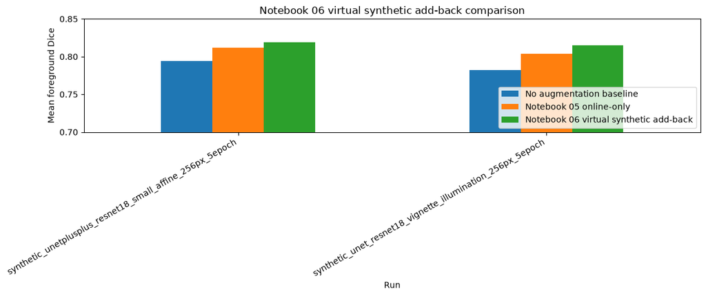

```python
# 06.20 — Plot synthetic expansion comparisons
plot_frame = synthetic_summary[
    [
        "run_name",
        "no_aug_baseline_mean_foreground_dice",
        "online_reference_mean_foreground_dice",
        "val_mean_foreground_dice",
    ]
].copy()

plot_frame = plot_frame.rename(
    columns={
        "no_aug_baseline_mean_foreground_dice": "No augmentation baseline",
        "online_reference_mean_foreground_dice": "Notebook 05 online-only",
        "val_mean_foreground_dice": "Notebook 06 virtual synthetic add-back",
    }
)

plot_frame = plot_frame.set_index("run_name")

ax = plot_frame.plot(kind="bar", figsize=(12, 5))
ax.set_title("Notebook 06 virtual synthetic add-back comparison")
ax.set_ylabel("Mean foreground Dice")
ax.set_xlabel("Run")
ax.set_ylim(0.70, max(0.85, float(plot_frame.max().max()) + 0.02))
ax.legend(loc="lower right")

plt.xticks(rotation=30, ha="right")
plt.tight_layout()
plt.show()
```

## 06.21 — Final Notebook 06 handoff summary

Summarize which synthetic expansion results are ready to carry forward.

```python
# 06.21 — Final Notebook 06 handoff summary
completed_runs = set(load_csv_if_exists(SYNTHETIC_HISTORY_PATH).get("run_name", []))
planned_runs = set(synthetic_training_plan["run_name"])

handoff_rows = [
    {
        "item": "virtual synthetic design",
        "status": "complete",
        "detail": "synthetic samples are produced on demand; no expanded image/mask dataset is saved",
    },
    {
        "item": "planned core runs",
        "status": "complete" if planned_runs.issubset(completed_runs) else "partial",
        "detail": f"{len(completed_runs.intersection(planned_runs))} of {len(planned_runs)} planned runs completed",
    },
    {
        "item": "summary CSV",
        "status": "ready" if SYNTHETIC_SUMMARY_PATH.exists() else "pending",
        "detail": str(SYNTHETIC_SUMMARY_PATH.relative_to(PROJECT_ROOT)),
    },
    {
        "item": "primary comparison",
        "status": "ready" if SYNTHETIC_SUMMARY_PATH.exists() else "pending",
        "detail": "compare virtual synthetic add-back against no-augmentation and online-only references",
    },
]

if SYNTHETIC_SUMMARY_PATH.exists():
    best_row = pd.read_csv(SYNTHETIC_SUMMARY_PATH).sort_values(
        "val_mean_foreground_dice",
        ascending=False,
    ).head(1)

    if not best_row.empty:
        handoff_rows.append(
            {
                "item": "best Notebook 06 run",
                "status": "identified",
                "detail": (
                    f"{best_row.iloc[0]['run_name']} "
                    f"mean Dice={best_row.iloc[0]['val_mean_foreground_dice']:.4f}"
                ),
            }
        )

handoff = pd.DataFrame(handoff_rows)
display(handoff)
```

|  | item | status | detail |
| --- | --- | --- | --- |
| 0 | virtual synthetic design | complete | synthetic samples are produced on demand; no e... |
| 1 | planned core runs | complete | 2 of 2 planned runs completed |
| 2 | summary CSV | ready | reports/training/synthetic_expansion_summary.csv |
| 3 | primary comparison | ready | compare virtual synthetic add-back against no-... |
| 4 | best Notebook 06 run | identified | synthetic_unetplusplus_resnet18_small_affine_2... |